# TP Integrador - Aprendizaje Estadístico

Santiago Bertero - Lautaro De Lucia

2023-01-17

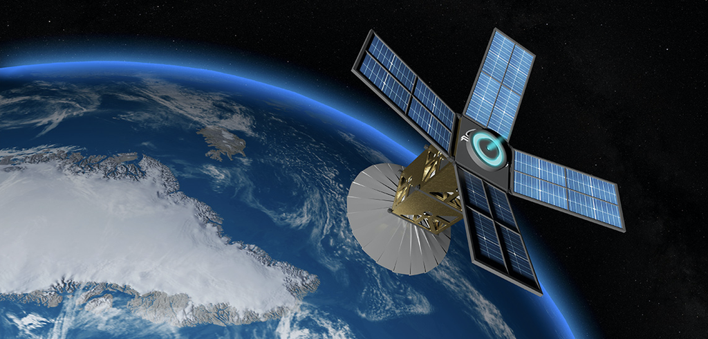

## **Enunciado**

En el archivo *sat.txt* se tienen datos de valores de espectros de pixels en una imagen de satélite utilizados para la *predicción de la clase de suelo*. Realice un análisis de los datos utilizando diferentes métodos y compárelos mediante Validación Cruzada. Luego aplíquelos a la muestra de test *sat.tst* y analice los resultados obtenidos.

## **Descripción de los Datos**

#### **Propósito**

La base de datos contiene los valores multi-espectrales de píxeles en regiones de 3x3 en una imágen satelital, y la clasificación asociada con el píxel central de cada región. El objetivo es predecir esta clasificación dados los valores multi-espectrales.

#### **Detalle**

Esta base de datos se generó a partir del *escáner multi-espectral LANDSAT*. Un marco de imágenes Landsat MSS consta de *cuatro imágenes* digitales de la misma escena en *diferentes bandas espectrales*. Dos de estos están en la región visible (correspondiente aproximadamente a las regiones verdes y rojas del espectro visible) y dos están en el infrarrojo. Cada *píxel* es una palabra binaria de 8 bits, con *0* correspondiente al negro y *255* a blanco. La resolución espacial de un píxel es de unos 80 m x 80m. Cada imagen contiene 2340 x 3380 de tales píxeles.

La base de datos es una subárea (pequeña) de una escena, que consta de 82 x 100 píxeles. *Cada línea de datos corresponde a una región de píxeles cuadrados 3x3* completamente contenida dentro de la subárea 82x100. Cada línea contiene los valores de píxeles en las cuatro bandas espectrales (convertidas en ASCII) de cada uno de los 9 píxeles en la región 3x3 y un número que indica la etiqueta de clasificación del píxel central.

La *clase* de cada píxel se codifica como un número, siendo estos:

- *1:* suelo rojo
- *2:* cultivo de algodón
- *3:* suelo gris
- *4:* suelo gris húmdeo
- *5:* suelo con rastrojo de vegetación
- *6:* mezcla de suelos
- *7:* suelo gris muy húmedo
  - **N.B**: No hay ejemplos con la clase 6 en este conjunto de datos (fueron removidos debido a dudas respecto a la validez de esta clase). Los datos se dan en orden aleatorio y se han eliminado ciertas líneas de datos para que no pueda reconstruir la imagen original a partir de este conjunto de datos.

En cada línea de datos, *los cuatro valores espectrales para el píxel superior izquierdo se dan primero*, seguidos por los cuatro valores espectrales para el píxel medio superior y luego los del píxel superior derecho, y así sucesivamente de modo que *los píxeles se leen en secuencia de izquierda a derecha y de arriba a abajo*. Por lo tanto, los cuatro valores espectrales para los píxeles centrales están dados por los atributos 17,18,19 y 20. *Si lo desea, puede usar solo estos cuatro atributos*, ignorando los demás.

- *DATOS TOTALES* → set de entrenamiento: 4435 set de prueba: 2000
- *CANTIDAD DE ATRIBUTOS* → 36 (4 bandas espectrales x 9 píxeles en una región)
- *ATRIBUTOS* → numéricos en el rango {0,255}
- *CLASES* → 6 en total: {1,2,3,4,5,7}

## **Resolución**

### **Obtención del Set de Datos**

Dado que el enunciado menciona que pueden utilizarse solo los datos espectrales correspondientes al píxel central, buscamos extraerlos, junto con su clasificación, a una sola dataframe.

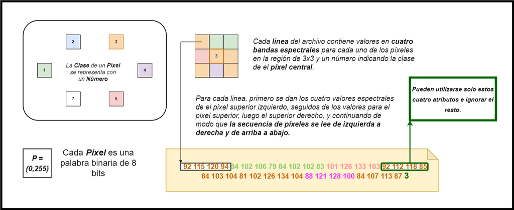

```r
file_trn = "SAT_trn.txt"
data_trn <- read.table(file_trn, sep = "", header=F)
sat_trn_df <- data_trn      %>%
  select(17:20,37)  %>%
  rename(B1=V17,
         B2=V18,
         B3=V19,
         B4=V20,
         C=V37)
file_tst = "SAT_tst.txt"
data_tst <- read.table(file_tst, sep = "", header=F)
sat_tst_df <- data_tst      %>%
  select(17:20,37)  %>%
  rename(B1=V17,
         B2=V18,
         B3=V19,
         B4=V20,
         C=V37)
```

```r
sat_trn_df$C[sat_trn_df$C == 7] <- 6
sat_tst_df$C[sat_tst_df$C == 7] <- 6
sat_trn_df_numeric <- data.frame(sat_trn_df)
sat_tst_df_numeric <- data.frame(sat_tst_df)
class_names <- c("rojo", "algodón", "gris","gris húmedo", "vegetación", "gris muy húmedo")
class_values <- c(1,2,3,4,5,6)
class_map <- setNames(class_names, class_values)
sat_trn_df$C <- class_map[sat_trn_df$C]
sat_tst_df$C <- class_map[sat_tst_df$C]
```

## **Visualización de los Datos**

#### Contenido del Set de Datos

| B1 | B2 | B3 | B4 | C |
| --- | --- | --- | --- | --- |
| 92 | 112 | 118 | 85 | gris |
| 84 | 103 | 104 | 81 | gris |
| 84 | 99 | 104 | 78 | gris |
| 84 | 99 | 104 | 81 | gris |
| 76 | 99 | 104 | 81 | gris |
| 76 | 99 | 108 | 85 | gris |
| 80 | 112 | 118 | 88 | gris |
| 80 | 107 | 113 | 85 | gris |
| 76 | 91 | 104 | 74 | gris húmedo |
| 76 | 95 | 100 | 78 | gris húmedo |

Podemos comprobar que tenemos valores acotados entre 0 y 255 para cuatro bandas espectrales y una categoría de suelo asignada en cada fila. Los contenidos pueden visualizarse mejor utilizando un gráfico de coordenadas paralelas.

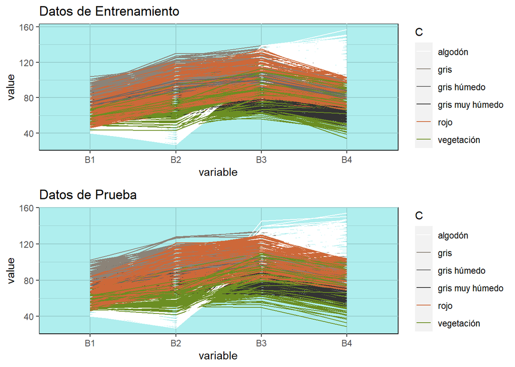

Donde cada linea representa una observación para las 4 bandas. La normalización de los valores no es necesaria ya que $B_1:B_4$ estan en la misma escala. Podemos ver que la distribución de suelo en los datos de entrenamiento y prueba es practicamente la misma.

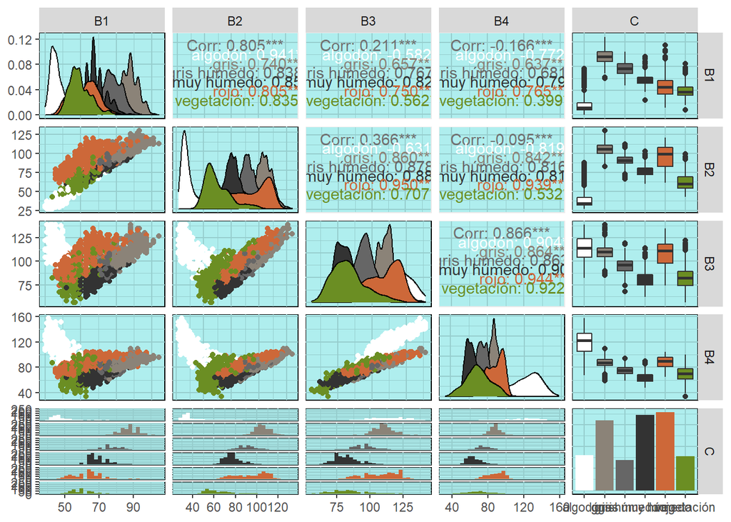

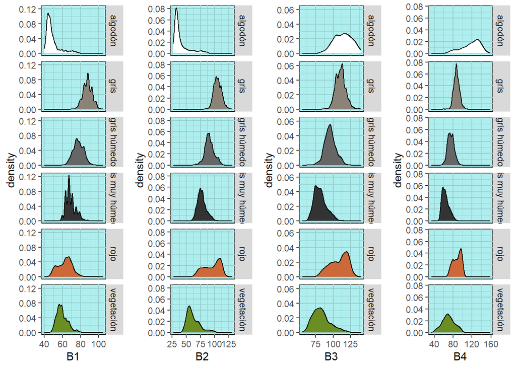

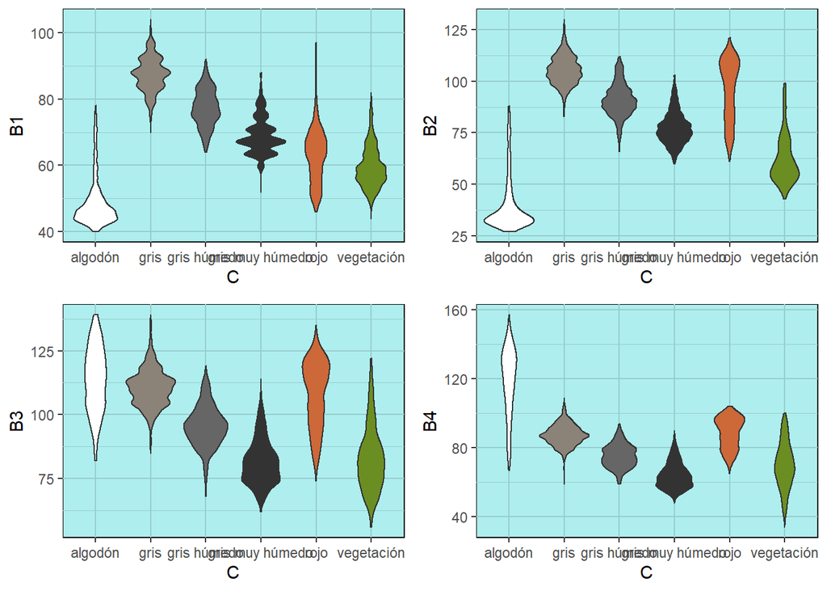

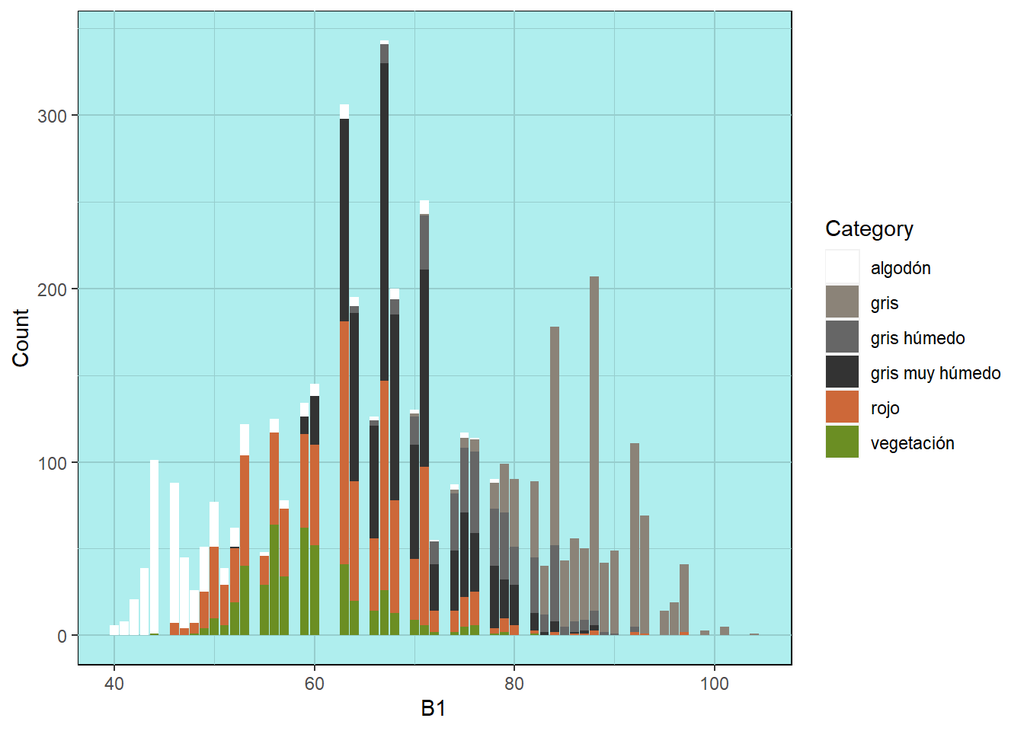

## **Construcción de Modelos**

```r
sat_trn_df <- data.frame(sat_trn_df_numeric)
sat_tst_df <- data.frame(sat_tst_df_numeric)
sat_trn_df$C <- as.factor(sat_trn_df$C)
sat_tst_df$C <- as.factor(sat_tst_df$C)
set.seed(20)
```

### Librería Tree

```r
# Entrenamiento del Modelo
n <- nrow(sat_trn_df)
sat_tree <- tree(C ~ B1 + B2 + B3 + B4,
                 data= sat_trn_df,
                 control=tree.control(
                   nobs= nrow(sat_trn_df),
                   mincut = 1,
                   minsize = 2,
                   mindev = 0)
                 )
# Resultados
sat_tree_summary <- summary(sat_tree)
EEnt <- sat_tree_summary$misclass[1] / n
sat_tree_summary
```

```
##
## Classification tree:
## tree(formula = C ~ B1 + B2 + B3 + B4, data = sat_trn_df, control = tree.control(nobs = nrow(sat_trn_df),
##     mincut = 1, minsize = 2, mindev = 0))
## Number of terminal nodes:  761
## Residual mean deviance:  0.1723 = 633 / 3674
## Misclassification error rate: 0.04014 = 178 / 4435
```

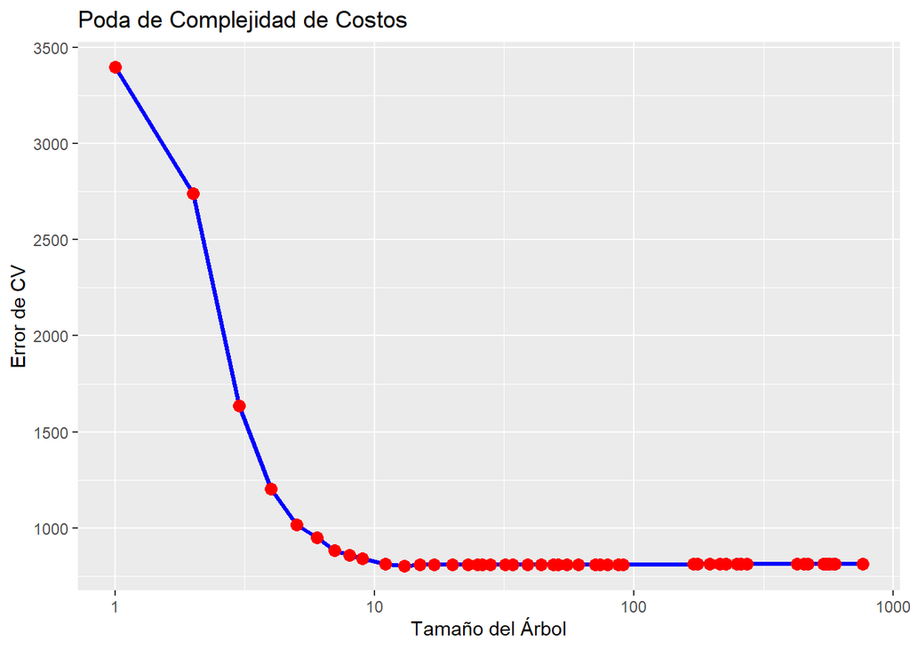

```r
sat_tree_CV = cv.tree(sat_tree, FUN = prune.misclass)
size <- sat_tree_CV$size
dev <- sat_tree_CV$dev
sp <-ggplot(data=data.frame(size,dev), aes(x=size, y=dev)) +
  geom_line(linetype="solid", color="blue", size=1.2)+
  geom_point(color="red", size=3)+
  labs(x= "Tamaño del Árbol", y = "Error de CV",title="Poda de Complejidad de Costos")
sp + scale_x_continuous(trans='log10')
```

```r
# Agrego código para obtener con R el mejor Tamaño
best_size <- which.min(sat_tree_CV$dev)
best_size
```

```
## [1] 39
```

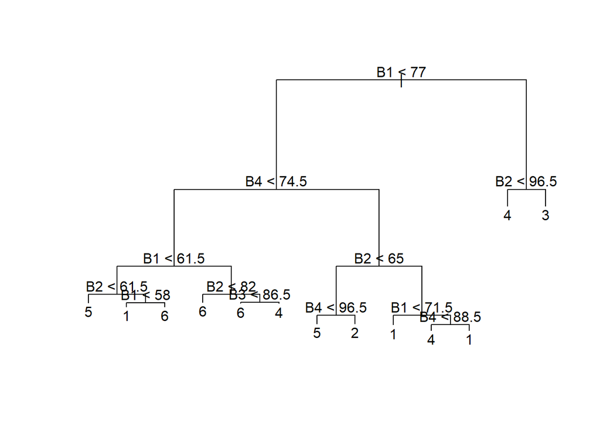

```r
# PQ Harcodea el 13?
sat_tree_prune = prune.misclass(sat_tree, best = 13)
plot(sat_tree_prune)
text(sat_tree_prune, pretty = 0)
```

```r
CVErr_tree <- sat_tree_CV$dev[39] / n
CVErr_tree
```

```
## [1] 0.1815107
```

### Librería RPart

```r
set.seed(20)
# Entrenamiento del Modelo con 10-fold CV
sat_rpart <-  rpart(C ~ B1 + B2 + B3 + B4, data= sat_trn_df, method = "class", cp=-1,xval=10)
sat_rpart_summary <- printcp(sat_rpart)
```

```
##
## Classification tree:
## rpart(formula = C ~ B1 + B2 + B3 + B4, data = sat_trn_df, method = "class",
##     cp = -1, xval = 10)
##
## Variables actually used in tree construction:
## [1] B1 B2 B3 B4
##
## Root node error: 3363/4435 = 0.75829
##
## n= 4435
##
##             CP nsplit rel error  xerror      xstd
## 1   2.6167e-01      0   1.00000 1.00000 0.0084779
## 2   2.5335e-01      1   0.73833 0.76896 0.0097636
```

[output cut: 26 more lines]

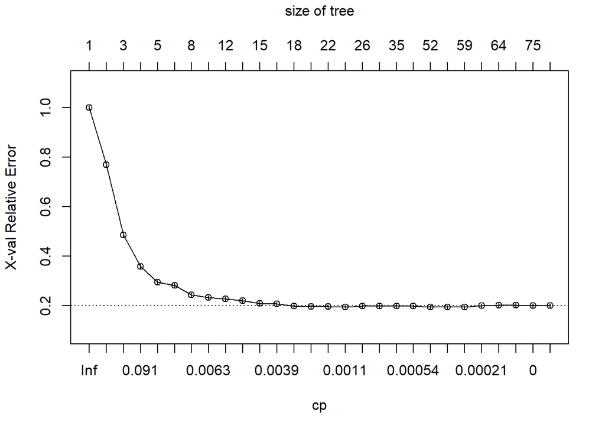

```r
plotcp(sat_rpart)
```

```r
which.min(sat_rpart$cptable[,4])
```

```
## 22
## 22
```

```r
cp<-sat_rpart$cptable[which.min(sat_rpart$cptable[,"xerror"]),"CP"]
cp
```

```
## [1] 0.0003964714
```

```r
CVErr_rpart = sat_rpart$frame[1,'dev'] / n * sat_rpart$cptable[which.min(sat_rpart$cptable[,"xerror"]),"xerror"]
CVErr_rpart
```

```
## [1] 0.1465614
```

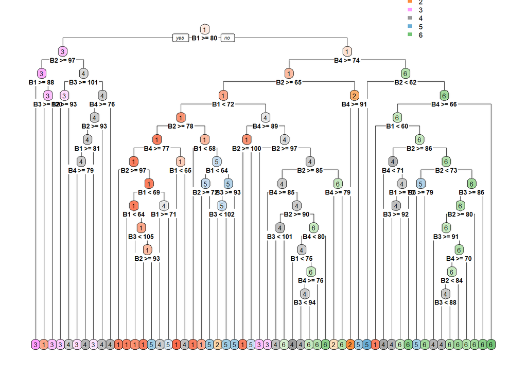

```r
poda_rpart<-prune(sat_rpart,cp=cp)
rpart.plot(poda_rpart, cex = 0.5, extra = 0)
```

### **Random Forest**

```r
set.seed(20)
sat_rf<- randomForest(C~., data= sat_trn_df,
                     mtry=sqrt(ncol(sat_trn_df)-1), importance=TRUE)

importance(sat_rf)
```

```
##            1        2         3        4         5        6
## B1 227.87903 29.96135 362.16076 58.21353  50.21856 48.37936
## B2 140.86987 43.00905  53.51638 37.62347 112.03571 41.93234
## B3  30.04423 10.40657  24.77468 15.11574  28.56435 32.31841
## B4  57.76868 24.80617  34.26451 35.82601  52.16778 74.12139
##    MeanDecreaseAccuracy MeanDecreaseGini
## B1            186.14425        1186.7218
## B2            119.11363         914.1809
## B3             48.88156         425.2869
## B4             91.94379         853.1770
```

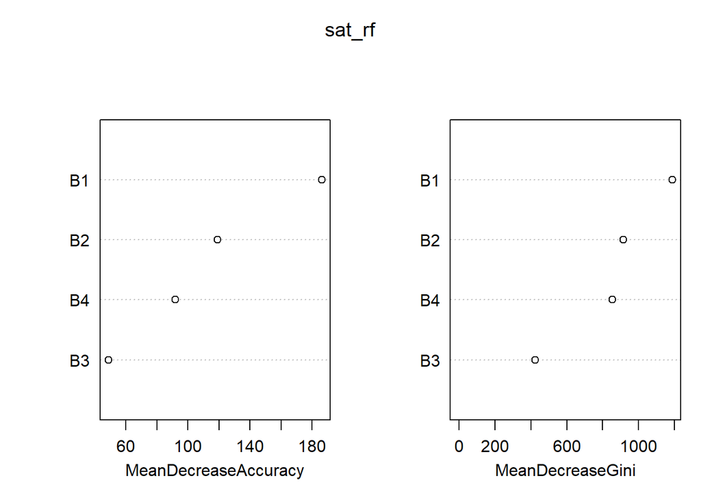

```r
varImpPlot(sat_rf)
```

```r
CVErr_rf <- unname(sat_rf$err.rate[nrow(sat_rf$err.rate),1])
CVErr_rf
```

```
## [1] 0.1492672
```

- *Obs:* Del análisis previo concluimos que el valor del pixel central en la primera banda es el principal predictor de la clase.

### **Vecinos Más Cercanos**

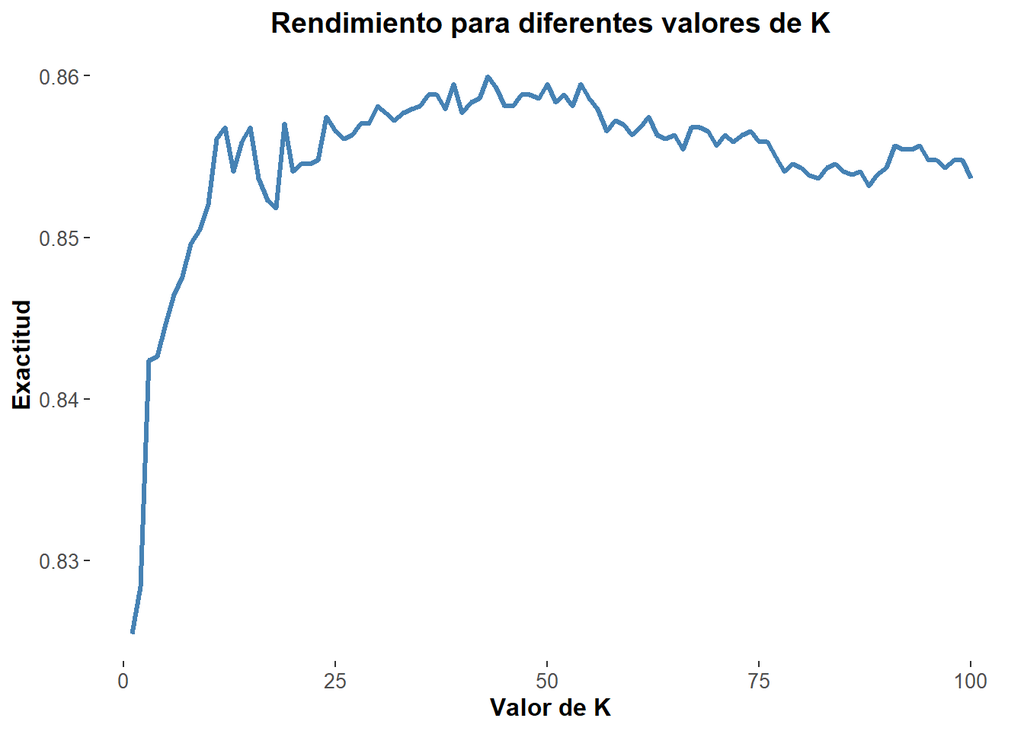

```r
set.seed(20)
sat_knn <- train(C ~ ., data = sat_trn_df,
                   method = "knn",
                   preProcess = c("center","scale"),
                   trControl =  trainControl(method = "cv", number = 10),
                   tuneGrid = expand.grid(k = 1:100),
                   metric = "Accuracy")
results <- sat_knn$results
ggplot(results, aes(x = k, y = Accuracy)) +
  geom_line(color = "steelblue", size = 1.2) +
  xlab("Valor de K") +
  ylab("Exactitud") +
  ggtitle("Rendimiento para diferentes valores de K") +
  theme_bw() +
  theme(plot.title = element_text(face = "bold", size = 14, hjust = 0.5),
        axis.title.x = element_text(face = "bold", size = 12),
        axis.title.y = element_text(face = "bold", size = 12),
        axis.text = element_text(size = 10),
        panel.grid.major = element_blank(),
        panel.grid.minor = element_blank(),
        panel.border = element_blank(),
        panel.background = element_blank())
```

```r
best_k <- results$k[which.max(results$Accuracy)]
best_k
```

```
## [1] 43
```

```r
CVErr_KNN <- 1-unname(sat_knn$results[best_k,"Accuracy"])
CVErr_KNN
```

```
## [1] 0.1400425
```

### **Regresión Logística Multinomial**

```r
summary(sat_mlr)
```

```
## Call:
## nnet::multinom(formula = .outcome ~ ., data = dat, decay = param$decay)
##
## Coefficients:
##   (Intercept)        B1          B2          B3         B4
## 2   -9.921154 0.5867093 -0.63317495  0.29943995 -0.1122932
## 3  -36.648978 0.7617752 -0.02673514  0.02795903 -0.2534971
## 4  -10.253548 0.5886442 -0.07999703 -0.02004337 -0.2854203
## 5    7.594031 0.4558313 -0.52173889  0.21832973 -0.2099831
## 6    4.599893 0.5678520 -0.18940106 -0.05394639 -0.2887664
##
## Std. Errors:
##   (Intercept)         B1         B2         B3         B4
## 2   1.6977543 0.05040409 0.04477873 0.05284647 0.04508065
## 3   1.2832527 0.03391253 0.03743092 0.04631104 0.04434272
## 4   0.8182467 0.03437754 0.03467115 0.04409015 0.04040293
## 5   0.9108139 0.03161938 0.03489501 0.04077884 0.03601165
## 6   0.7841282 0.03491517 0.03359844 0.04276092 0.03778148
##
## Residual Deviance: 3755.425
## AIC: 3805.425
```

```r
#sat_mlr <- nnet::multinom(C ~ ., data = sat_trn_df)
#summary(sat_rl)
# Predict the class labels for the training data
confusion_matrix <- confusionMatrix(predict(sat_mlr, newdata = sat_trn_df), sat_trn_df$C)
confusion_matrix$overall['Accuracy']
```

```
##  Accuracy
## 0.8430665
```

```r
predicted_mlr <- predict(sat_mlr, newdata = sat_trn_df)

CVErr_mlr <- mean(predicted_mlr != sat_trn_df$C)
CVErr_mlr
```

```
## [1] 0.1569335
```

```r
#pred_nnet <- predict(model_nnet, newdata = sat_tst_df, type = "class")
#accuracy_nnet <- mean(pred_nnet == sat_tst_df$C)
#cat("Accuracy score for nnet:", round(accuracy_nnet, 3), "\n")
```

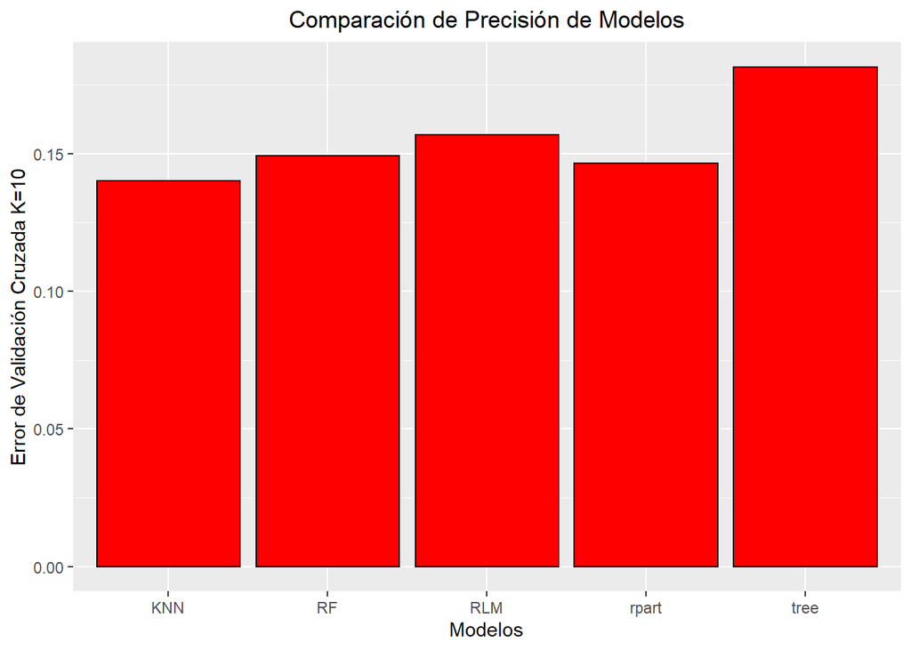

```r
models <- c("tree", "rpart", "RF", "KNN", "RLM")
CVErrs <- c(CVErr_tree,CVErr_rpart,CVErr_rf,CVErr_KNN,CVErr_mlr)

# Combine the arrays into a data frame
CVErr_df <- data.frame(Label = models, Value = CVErrs)

# Plot a bar chart using ggplot2
ggplot(CVErr_df, aes(x = Label, y = Value)) +
  geom_bar(stat = "identity", color = "black", fill = "red") + labs(x = "Modelos", y = "Error de Validación Cruzada K=10", title = "Comparación de Precisión de Modelos") +
  theme(plot.title = element_text(hjust = 0.5))
```

```r
#conf_mat <- caret::confusionMatrix(pred_nnet, sat_tst_df$C)
#conf_mat
```

```r
#conf_matrix(sat_tst_df$C,pred_nnet)
```

```r
#probs <- predict(model_nnet, newdata = sat_tst_df, type = "probs")
#ROC <- multiclass.roc(response = sat_tst_df$C, predictor = probs)
```

```r
#auc(ROC)
```

### **Árbol de Clasificación**

### Librería Tree

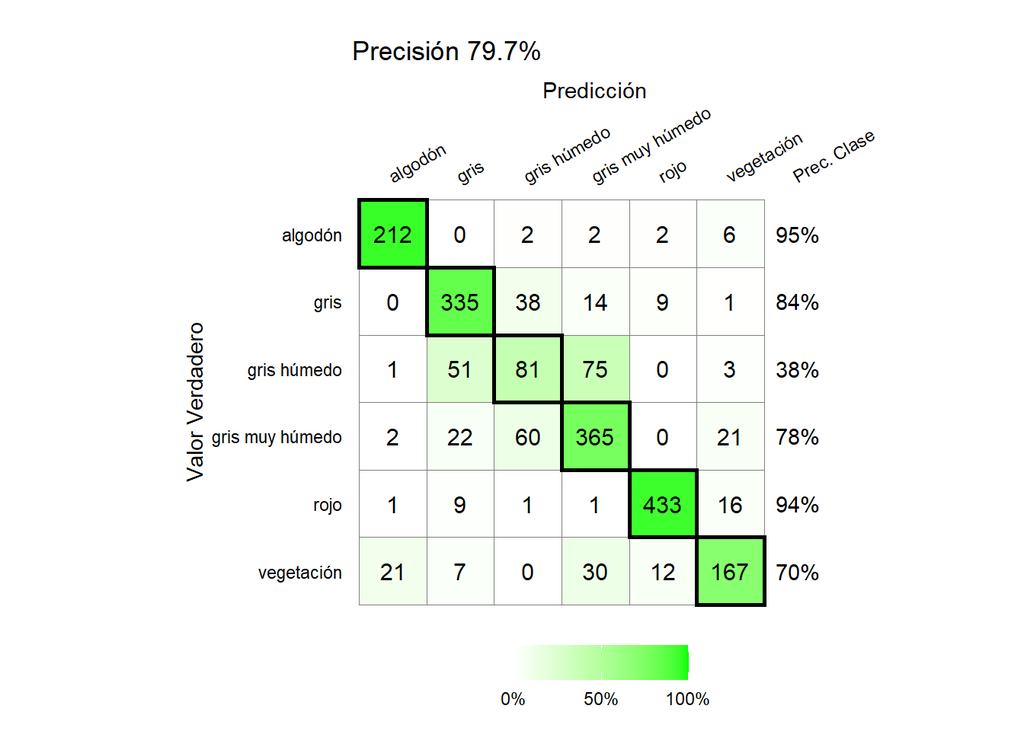

### Librería Rpart

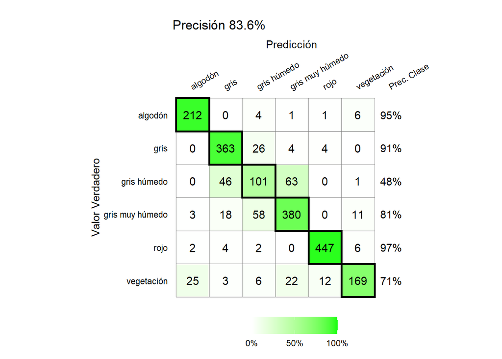

### **Random Forest**

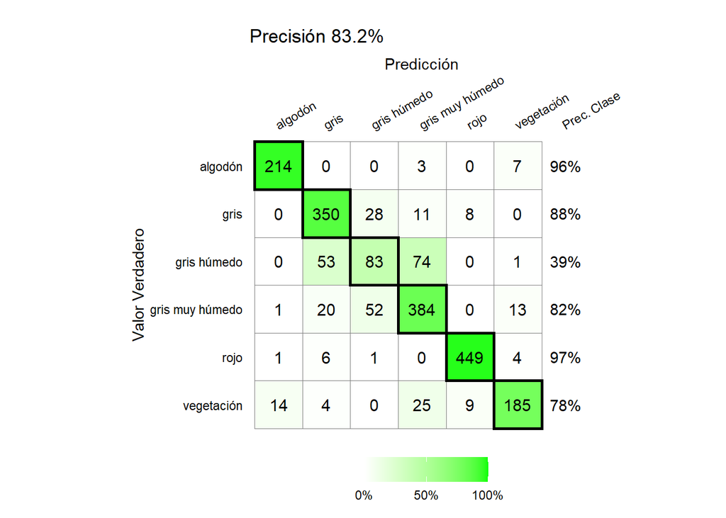

### **Regresión Logística Multinomial**

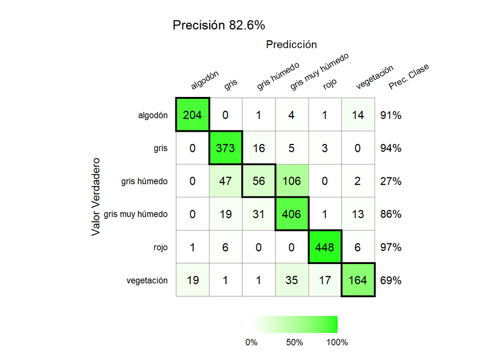

### **Vecinos Más Cercanos**

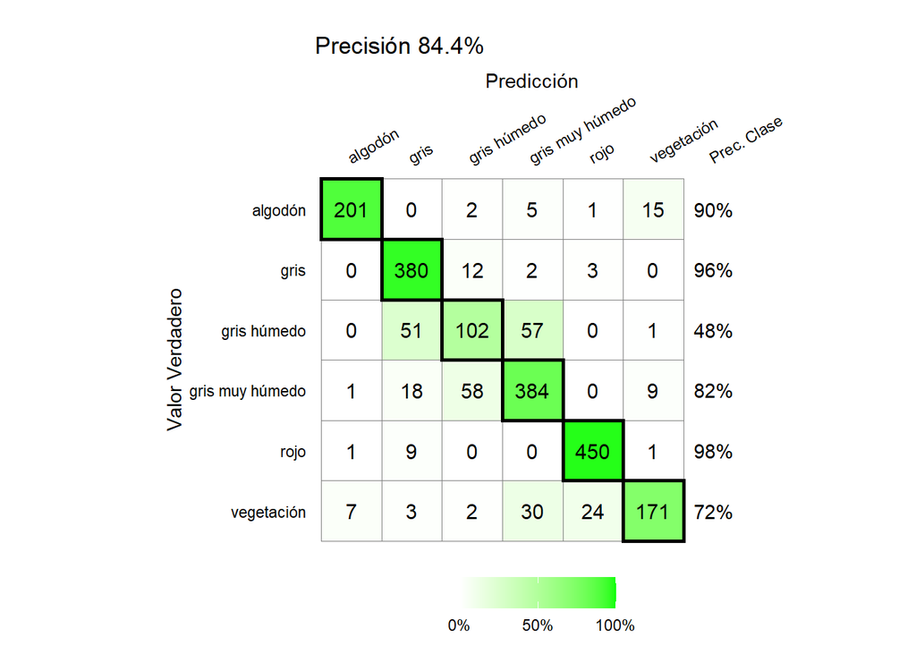

### **ANEXO: Análisis Para el Set de Datos Completo**

Queremos comprobar:

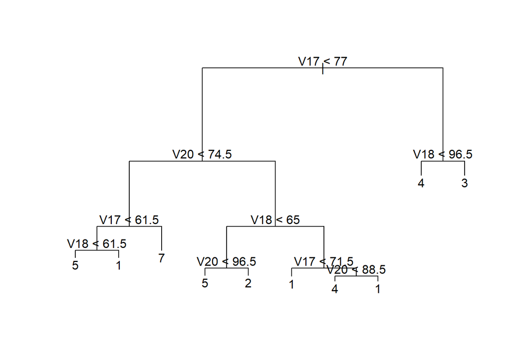

```r
sat_trn_df_full <- data_trn
sat_trn_df_full$V37 <- as.factor(sat_trn_df_full$V37)

n <- nrow(sat_trn_df_full)
full_tree <- tree(V37 ~., data= sat_trn_df_full, control=tree.control(nobs= nrow(sat_trn_df_full), mincut = 1, minsize = 2))
full_tree_summary <- summary(full_tree)
EEnt <- full_tree_summary$misclass[1] / n
#full_tree_summary

set.seed(20)
full_tree_CV = cv.tree(full_tree, FUN = prune.misclass)
full_size <- full_tree_CV$size
full_dev <- full_tree_CV$dev
#ggplot(data=data.frame(full_size,full_dev), aes(x=full_size, y=full_dev)) +
#  geom_line(linetype="solid", color="blue", size=1.2)+
#  geom_point(color="red", size=3)+
#  labs(x= "Tamaño del Árbol", y = "Error de CV",title="Poda de Complejidad de Costos")

prune_full = prune.misclass(full_tree, best = 10)
plot(prune_full)
text(prune_full, pretty = 0)
```

```r
set.seed(20)
full_tree_2 <-  rpart(V37 ~., data= sat_trn_df_full, method = "class", cp=-1,xval=10)
full_tree_2_summary <- printcp(full_tree_2)
```

```
##
## Classification tree:
## rpart(formula = V37 ~ ., data = sat_trn_df_full, method = "class",
##     cp = -1, xval = 10)
##
## Variables actually used in tree construction:
##  [1] V1  V10 V11 V12 V13 V14 V15 V16 V17 V18 V19 V2  V20 V21 V22 V23 V24 V25 V26
## [20] V27 V28 V29 V3  V30 V31 V32 V33 V34 V35 V36 V4  V5  V6  V7  V8  V9
##
## Root node error: 3363/4435 = 0.75829
##
## n= 4435
##
##             CP nsplit rel error  xerror      xstd
## 1   0.26167113      0   1.00000 1.00000 0.0084779
```

[output cut: 33 more lines]

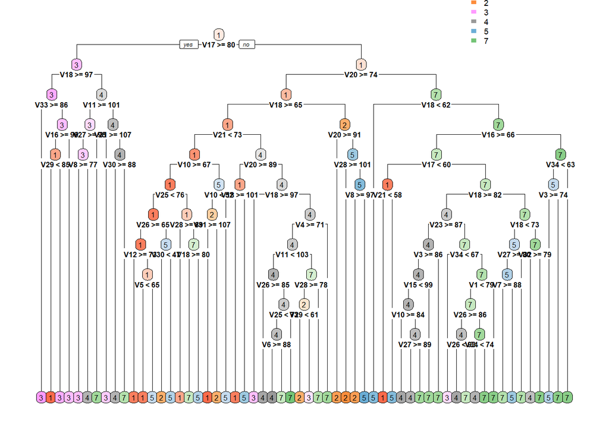

```r
full_tree_2_NP_pred <- predict(full_tree_2, sat_trn_df_full, type = "class")
# Poda
#full_tree_2$cptable
#plotcp(full_tree_2) #grafico
#which.min(full_tree_2$cptable[,4])
cp<-full_tree_2$cptable[which.min(full_tree_2$cptable[,"xerror"]),"CP"]
poda<-prune(full_tree_2,cp=cp)
rpart.plot(poda, cex = 0.5, extra = 0)
```

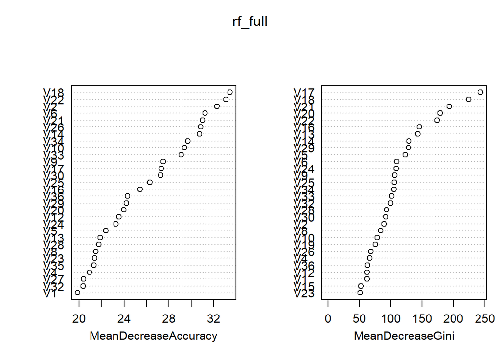

```r
set.seed(20)
rf_full<- randomForest(V37~., data= sat_trn_df_full,
                     mtry=sqrt(ncol(sat_trn_df_full)-1), importance=TRUE)

#importance(rf_full)
varImpPlot(rf_full)
```

```r
unname(rf_full$err.rate[nrow(rf_full$err.rate),1])
```

```
## [1] 0.08568207
```